# Brauer et al. (2008): Figure 2 Reproduction

Bin via Codex

2026-06-18 updated 2026-06-18

# Setup

This analysis reproduces the hierarchically clustered expression matrix in Figure 2 using the authors’ processed data. Code is folded by default and can be expanded using the **Code** controls.

```r
knitr::opts_chunk$set(echo = TRUE, message = FALSE, warning = FALSE)

pkgs_cran <- c("pheatmap", "here")
pkgs_bio  <- c("GEOquery")

if (!requireNamespace("BiocManager", quietly = TRUE))
  install.packages("BiocManager")

for (p in pkgs_bio)
  if (!requireNamespace(p, quietly = TRUE)) BiocManager::install(p)

for (p in pkgs_cran)
  if (!requireNamespace(p, quietly = TRUE)) install.packages(p)

suppressPackageStartupMessages({
  library(GEOquery)
  library(pheatmap)
  library(here)
})

i_am("analysis/20260618-Brauer-2008-reanalysis.Rmd")

input_dir  <- here("input")
output_dir <- here("output")
#dir.create(input_dir, recursive = TRUE, showWarnings = FALSE)
#dir.create(output_dir, recursive = TRUE, showWarnings = FALSE)

download_if_missing <- function(url, path) {
  if (!file.exists(path)) {
    message("Downloading ", basename(path), " ...")
    utils::download.file(url, path, mode = "wb", quiet = FALSE)
  } else {
    message("Using cached ", basename(path))
  }
}
```

# Acquire processed data and current annotations

The analysis caches the authors’ raw TXT and CDT files, the latest available GPL884 record, and current SGD feature tables under `input/`. Existing files are never overwritten.

```r
raw_path <- file.path(input_dir, "dilution_rate_00_raw.txt")
cdt_path <- file.path(input_dir, "dilution_rate_00_raw.cdt")
gpl_path <- file.path(input_dir, "GPL884.soft.gz")
sgd_path <- file.path(input_dir, "SGD_features.tab")
deleted_path <- file.path(input_dir, "deleted_merged_features.tab")

download_if_missing(
  "http://growthrate.princeton.edu/data/dilution_rate_00_raw.txt",
  raw_path
)
download_if_missing(
  "http://growthrate.princeton.edu/data/dilution_rate_00_raw.cdt",
  cdt_path
)
download_if_missing(
  "https://downloads.yeastgenome.org/curation/chromosomal_feature/SGD_features.tab",
  sgd_path
)
download_if_missing(
  "https://downloads.yeastgenome.org/curation/chromosomal_feature/deleted_merged_features.tab",
  deleted_path
)

if (!file.exists(gpl_path)) {
  message("Downloading current GPL884 annotation through GEOquery ...")
  getGEO("GPL884", destdir = input_dir)
}
```

# Reconcile the raw TXT and clustering CDT

The TXT is the authoritative numeric source. The CDT is used to validate row identity and to recover its historical gene and probe identifiers.

```r
raw_data <- read.delim(
  raw_path, check.names = FALSE, na.strings = "", quote = "\"",
  stringsAsFactors = FALSE
)
cdt_data <- read.delim(
  cdt_path, check.names = FALSE, na.strings = "", quote = "\"",
  stringsAsFactors = FALSE
)

expr_cols <- grep("^[GNPSLU]0\\.[0-9]+$", names(raw_data), value = TRUE)
stopifnot(
  nrow(raw_data) == 5537L,
  nrow(cdt_data) == 5537L,
  length(expr_cols) == 36L,
  identical(raw_data$GID, cdt_data$GID),
  identical(raw_data$YORF, cdt_data$UID)
)

expr_raw <- as.matrix(raw_data[, expr_cols, drop = FALSE])
expr_cdt <- as.matrix(cdt_data[, expr_cols, drop = FALSE])
storage.mode(expr_raw) <- "numeric"
storage.mode(expr_cdt) <- "numeric"
stopifnot(sum(is.na(expr_raw)) == 866L)

# The CDT contains the same ordered non-missing values, but omits interior
# delimiters in 359 rows. This shifts values left, so it is not a numeric source.
same_value_sequence <- vapply(seq_len(nrow(expr_raw)), function(i) {
  identical(
    as.vector(expr_raw[i, !is.na(expr_raw[i, ])]),
    as.vector(expr_cdt[i, !is.na(expr_cdt[i, ])])
  )
}, logical(1))
stopifnot(all(same_value_sequence))

cdt_position_disagreement <- rowSums(
  xor(is.na(expr_raw), is.na(expr_cdt)) |
    ((!is.na(expr_raw) & !is.na(expr_cdt)) & expr_raw != expr_cdt)
) > 0
stopifnot(sum(cdt_position_disagreement) == 359L)
```

Both files contain **5537 rows** in identical order and the same ordered non-missing measurements. The raw TXT contains **866 missing values**. The CDT shifts missing-value positions in **359 rows**, so it is not used as an expression matrix.

# Map probe IDs through GPL884 and current SGD

Each stable Agilent probe UID is linked to GPL884 and then reconciled against current SGD features, including deleted and merged-feature mappings. No rows are discarded based on current annotation status.

```r
gpl <- getGEO(filename = gpl_path)
gpl_table <- Table(gpl)
gpl_idx <- match(raw_data$YORF, gpl_table$SPOT_ID)
stopifnot(!anyNA(gpl_idx))

sgd_colnames <- c(
  "sgd_id", "feature_type", "qualifier", "feature_name",
  "standard_name", "aliases", "parent_feature", "secondary_sgd_id",
  "chromosome", "start", "stop", "strand", "genetic_position",
  "coordinate_version", "sequence_version", "description"
)
sgd <- read.delim(
  sgd_path, header = FALSE, col.names = sgd_colnames, quote = "",
  comment.char = "", fill = TRUE, stringsAsFactors = FALSE
)
deleted_colnames <- c(
  "old_feature_name", "old_feature_type_status", "chromosome", "start",
  "stop", "strand", "old_sgd_id", "old_secondary_sgd_id",
  "replacement_feature_name", "replacement_sgd_id", "description",
  "notes", "change_date"
)
deleted <- read.delim(
  deleted_path, header = FALSE, col.names = deleted_colnames, quote = "",
  comment.char = "", fill = TRUE, stringsAsFactors = FALSE
)

historical_id <- cdt_data$YORF
direct_idx <- match(historical_id, sgd$feature_name)
deleted_idx <- match(historical_id, deleted$old_feature_name)
replacement_id <- deleted$replacement_feature_name[deleted_idx]
replacement_id[is.na(replacement_id) | replacement_id == ""] <- NA_character_
current_id <- historical_id
current_id[is.na(direct_idx)] <- replacement_id[is.na(direct_idx)]
current_idx <- match(current_id, sgd$feature_name)

mapping_status <- ifelse(
  !is.na(direct_idx), "current",
  ifelse(!is.na(replacement_id), "merged_or_renamed", "unresolved")
)

gene_annotation <- data.frame(
  row_key = raw_data$YORF,
  gid = raw_data$GID,
  probe_uid = raw_data$YORF,
  cdt_historical_id = historical_id,
  gpl_orf = gpl_table$ORF[gpl_idx],
  gpl_feature_name = gpl_table$NAME[gpl_idx],
  gpl_gene_symbol = gpl_table$GENE_SYMBOL[gpl_idx],
  current_sgd_id = sgd$sgd_id[current_idx],
  current_systematic_id = current_id,
  current_standard_name = sgd$standard_name[current_idx],
  current_feature_type = sgd$feature_type[current_idx],
  current_qualifier = sgd$qualifier[current_idx],
  mapping_status = mapping_status,
  stringsAsFactors = FALSE
)

gpl_canonical_id <- ifelse(
  nzchar(gene_annotation$gpl_orf), gene_annotation$gpl_orf,
  gene_annotation$gpl_feature_name
)
gpl_cdt_disagreement <- gpl_canonical_id != historical_id

write.csv(
  gene_annotation,
  file.path(output_dir, "figure2_gene_annotation.csv"),
  row.names = FALSE, na = ""
)

# Stable, unique probe UIDs are retained as row keys even when historical
# features now resolve to the same SGD feature.
rownames(expr_raw) <- gene_annotation$row_key
```

All **5537 / 5537** probes map to GPL884. There are **4** GPL/CDT identifier disagreements, and **5536 / 5537** rows resolve to a current SGD feature.

Current SGD mapping outcomes

| Mapping status | Rows |
| --- | --- |
| current | 5519 |
| merged_or_renamed | 17 |
| unresolved | 1 |

Current SGD feature qualifiers

| SGD qualifier | Rows |
| --- | --- |
|  | 13 |
| Dubious | 162 |
| Uncharacterized | 30 |
| Verified | 5331 |
| NA | 1 |

The rows with empty “SGD qualifier” are either “blocked reading frame”, “transposable element gene”, or “pseudogene”. These are not excluded from the analysis, as they were present in the original data and may still be biologically relevant.

# Parse and validate sample metadata

Sample metadata are parsed directly from the 36 expression-column names and validated as the complete six-nutrient by six-dilution-rate design.

```r
metadata_match <- regexec("^([GNPSLU])(0\\.[0-9]+)$", expr_cols)
metadata_parts <- regmatches(expr_cols, metadata_match)
stopifnot(all(lengths(metadata_parts) == 3L))

pd_ordered <- data.frame(
  sample = expr_cols,
  nutrient = vapply(metadata_parts, `[`, character(1), 2L),
  dil_rate = as.numeric(vapply(metadata_parts, `[`, character(1), 3L)),
  stringsAsFactors = FALSE,
  row.names = expr_cols
)
pd_ordered$nutrient <- factor(
  pd_ordered$nutrient, levels = c("G", "N", "P", "S", "L", "U")
)

expected_design <- expand.grid(
  nutrient = c("G", "N", "P", "S", "L", "U"),
  dil_rate = c(0.05, 0.10, 0.15, 0.20, 0.25, 0.30),
  stringsAsFactors = FALSE
)
observed_design <- data.frame(
  nutrient = as.character(pd_ordered$nutrient),
  dil_rate = pd_ordered$dil_rate
)
stopifnot(
  !anyNA(pd_ordered),
  !anyDuplicated(observed_design),
  nrow(merge(expected_design, observed_design)) == 36L
)
```

Experimental conditions

|  | sample | nutrient | dil_rate |
| --- | --- | --- | --- |
| G0.05 | G0.05 | G | 0.05 |
| G0.1 | G0.1 | G | 0.10 |
| G0.15 | G0.15 | G | 0.15 |
| G0.2 | G0.2 | G | 0.20 |
| G0.25 | G0.25 | G | 0.25 |
| G0.3 | G0.3 | G | 0.30 |
| N0.05 | N0.05 | N | 0.05 |
| N0.1 | N0.1 | N | 0.10 |
| N0.15 | N0.15 | N | 0.15 |
| N0.2 | N0.2 | N | 0.20 |
| N0.25 | N0.25 | N | 0.25 |
| N0.3 | N0.3 | N | 0.30 |
| P0.05 | P0.05 | P | 0.05 |
| P0.1 | P0.1 | P | 0.10 |
| P0.15 | P0.15 | P | 0.15 |
| P0.2 | P0.2 | P | 0.20 |
| P0.25 | P0.25 | P | 0.25 |
| P0.3 | P0.3 | P | 0.30 |
| S0.05 | S0.05 | S | 0.05 |
| S0.1 | S0.1 | S | 0.10 |
| S0.15 | S0.15 | S | 0.15 |
| S0.2 | S0.2 | S | 0.20 |
| S0.25 | S0.25 | S | 0.25 |
| S0.3 | S0.3 | S | 0.30 |
| L0.05 | L0.05 | L | 0.05 |
| L0.1 | L0.1 | L | 0.10 |
| L0.15 | L0.15 | L | 0.15 |
| L0.2 | L0.2 | L | 0.20 |
| L0.25 | L0.25 | L | 0.25 |
| L0.3 | L0.3 | L | 0.30 |
| U0.05 | U0.05 | U | 0.05 |
| U0.1 | U0.1 | U | 0.10 |
| U0.15 | U0.15 | U | 0.15 |
| U0.2 | U0.2 | U | 0.20 |
| U0.25 | U0.25 | U | 0.25 |
| U0.3 | U0.3 | U | 0.30 |

# Figure 2 — Hierarchical clustering heatmap

All 5,537 rows are clustered using pairwise-complete Pearson correlation and average-linkage UPGMA. Missing measurements are shown in gray.

```r
row_sd <- apply(expr_raw, 1, sd, na.rm = TRUE)
stopifnot(all(is.finite(row_sd)), all(row_sd > 0))

gene_cor <- cor(t(expr_raw), use = "pairwise.complete.obs", method = "pearson")
stopifnot(all(is.finite(gene_cor)))
gene_dist <- as.dist(1 - gene_cor)
gene_clust <- hclust(gene_dist, method = "average")

# Column annotation: nutrient & dilution rate
col_ann <- data.frame(
  Nutrient = pd_ordered$nutrient,
  Rate = factor(pd_ordered$dil_rate),
  row.names = colnames(expr_raw)
)

nutrient_colors <- c(G = "#E41A1C", N = "#377EB8", P = "#4DAF4A",
                     S = "#984EA3", L = "#FF7F00", U = "#A65628")
rate_palette    <- colorRampPalette(c("white","#2C7BB6"))(6)
rate_breaks     <- sort(unique(pd_ordered$dil_rate))

ann_colors <- list(
  Nutrient = nutrient_colors,
  Rate     = setNames(rate_palette, as.character(rate_breaks))
)

# The original figure uses seven integer-centered color bins. Assigning values
# through matrix indexing preserves dimensions (unlike pmax() with a scalar as
# its first argument, which can drop the matrix attributes).
expr_binned <- round(expr_raw)
expr_binned[expr_binned < -3] <- -3
expr_binned[expr_binned > 3] <- 3

# Color scale matching paper: green = down, black = 0, red = up
# Paper uses log2 ratios (sample / glucose-limited 0.25 reference)
heatmap_colors <- c(
  "#008000", "#006000", "#003000",
  "#000000",
  "#500000", "#900000", "#CC0000"
)
heatmap_breaks <- seq(-3.5, 3.5, by = 1)
heatmap_labels <- -3:3

stopifnot(
  identical(dim(expr_binned), dim(expr_raw)),
  identical(dimnames(expr_binned), dimnames(expr_raw)),
  length(heatmap_breaks) == length(heatmap_colors) + 1L,
  length(heatmap_labels) == length(heatmap_colors),
  all(expr_binned[!is.na(expr_binned)] %in% heatmap_labels)
)
```

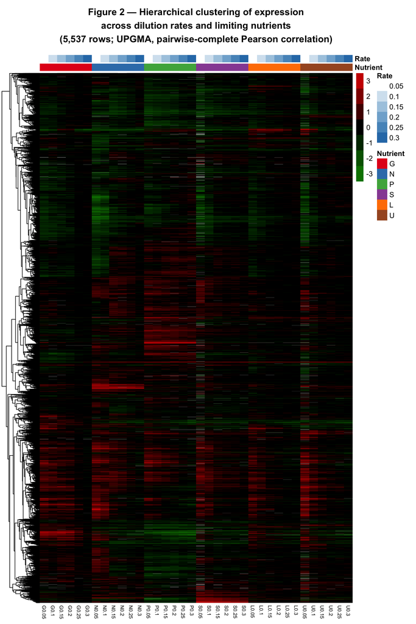

```r
figure2_path <- file.path(output_dir, "figure2_hierarchical_clustering.png")
png(figure2_path,
    width = 2400, height = 3600, res = 200)

pheatmap(
  mat               = expr_binned,
  color             = heatmap_colors,
  breaks            = heatmap_breaks,
  legend_breaks     = heatmap_labels,
  legend_labels     = as.character(heatmap_labels),
  cluster_cols      = FALSE,   # columns pre-ordered by nutrient/rate
  cluster_rows      = gene_clust,
  show_rownames     = FALSE,
  show_colnames     = TRUE,
  fontsize_col      = 7,
  annotation_col    = col_ann,
  annotation_colors = ann_colors,
  border_color      = NA,
  na_col            = "#BDBDBD",
  main = paste0(
    "Figure 2 — Hierarchical clustering of expression\n",
    "across dilution rates and limiting nutrients\n",
    "(5,537 rows; UPGMA, pairwise-complete Pearson correlation)"
  )
)
```

```r
dev.off()
```

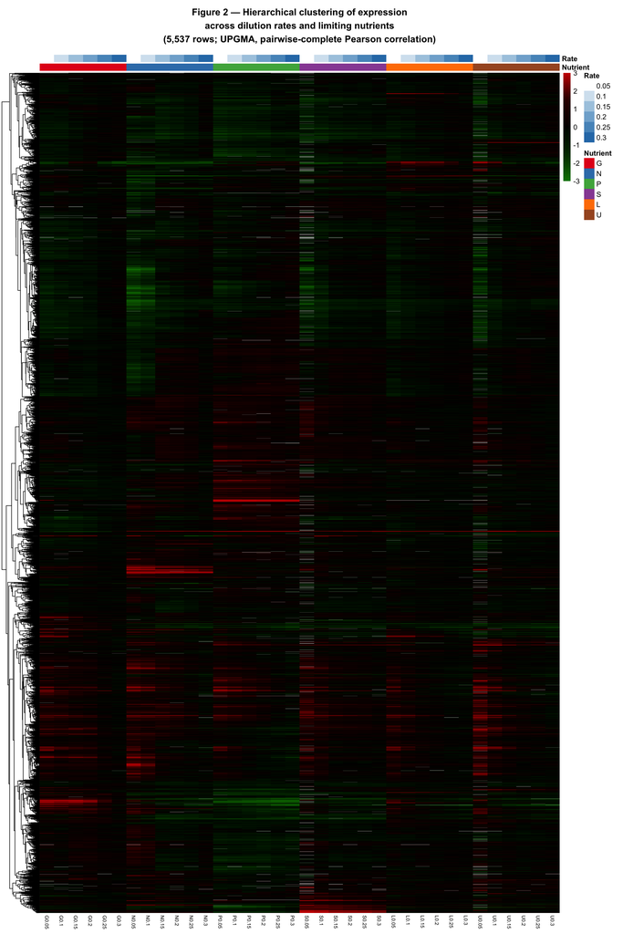

```r
knitr::include_graphics(figure2_path)
```

The reproduced heatmap is saved to `output/figure2_hierarchical_clustering.png`, and the annotation audit is saved to `output/figure2_gene_annotation.csv`.

# Identify the phosphate-specific cluster

The paper describes a 133-gene cluster induced specifically during phosphate limitation. Two complementary definitions are evaluated here. The fixed rule requires a strong average phosphate signal, a low non-phosphate background, a minimum phosphate contrast, and consistent phosphate elevation at every matched dilution rate. The distribution-based method ranks all rows by a robust phosphate-specificity score.

```r
is_p <- grepl("^P", colnames(expr_raw))
sample_rates <- sub("^[GNPSLU]", "", colnames(expr_raw))

mean_p <- rowMeans(expr_raw[, is_p, drop = FALSE], na.rm = TRUE)
mean_non_p <- rowMeans(expr_raw[, !is_p, drop = FALSE], na.rm = TRUE)
p_effect <- mean_p - mean_non_p

p_cols <- which(is_p)
p_consistency_count <- vapply(seq_len(nrow(expr_raw)), function(i) {
  sum(vapply(p_cols, function(j) {
    same_rate_non_p <- which(!is_p & sample_rates == sample_rates[j])
    is.finite(expr_raw[i, j]) &&
      expr_raw[i, j] > mean(expr_raw[i, same_rate_non_p], na.rm = TRUE)
  }, logical(1)))
}, integer(1))

# Fixed, interpretable thresholds on the log2 expression-ratio scale.
phosphate_fixed <- (
  mean_p >= 1 &
  mean_non_p <= 0.5 &
  p_effect >= 0.75 &
  p_consistency_count == length(p_cols)
)

# Robust distribution score: phosphate median contrast standardized by the
# non-phosphate median absolute deviation. The 0.1 floor prevents unstable
# scores for nearly invariant rows.
median_p <- apply(expr_raw[, is_p, drop = FALSE], 1, median, na.rm = TRUE)
median_non_p <- apply(
  expr_raw[, !is_p, drop = FALSE], 1, median, na.rm = TRUE
)
background_mad <- apply(
  expr_raw[, !is_p, drop = FALSE], 1, mad, na.rm = TRUE
)
p_specificity_score <- (
  median_p - median_non_p
) / (background_mad + 0.1)

p_specificity_rank <- rank(
  -p_specificity_score, ties.method = "first", na.last = "keep"
)
phosphate_ranked <- !is.na(p_specificity_rank) & p_specificity_rank <= 133

stopifnot(
  sum(phosphate_fixed) == 133L,
  sum(phosphate_ranked, na.rm = TRUE) == 133L
)

phosphate_candidates <- cbind(
  gene_annotation,
  mean_p = mean_p,
  mean_non_p = mean_non_p,
  p_effect = p_effect,
  p_consistency_count = p_consistency_count,
  median_p = median_p,
  median_non_p = median_non_p,
  background_mad = background_mad,
  p_specificity_score = p_specificity_score,
  p_specificity_rank = p_specificity_rank,
  fixed_threshold_member = phosphate_fixed,
  top_133_score_member = phosphate_ranked
)

phosphate_candidates <- phosphate_candidates[
  order(phosphate_candidates$p_specificity_rank, na.last = TRUE),
]

phosphate_output_path <- file.path(
  output_dir, "figure2_phosphate_specific_candidates.csv"
)
write.csv(
  phosphate_candidates,
  phosphate_output_path,
  row.names = FALSE,
  na = ""
)
```

The fixed rule identifies **133 rows**. The robust score independently selects its top **133 rows**. The two definitions share **72 rows** (Jaccard similarity **0.371**). The fixed-rule count reproduces the reported cluster size, but matching the number 133 alone does not establish that its membership is identical to the manually identified dendrogram branch in the paper.

Phosphate-specific candidate sets

| Method | Rows |
| --- | --- |
| Fixed thresholds | 133 |
| Top robust specificity scores | 133 |
| Intersection | 72 |

The fixed-rule candidates show the expected phosphate-specific block across the six matched dilution rates.

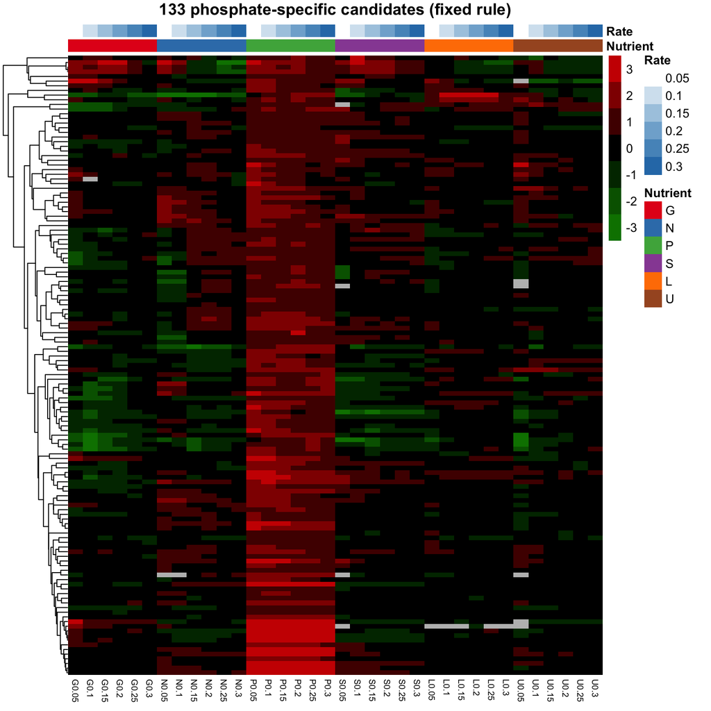

```r
phosphate_expr <- expr_raw[phosphate_fixed, , drop = FALSE]
phosphate_cor <- cor(
  t(phosphate_expr), use = "pairwise.complete.obs", method = "pearson"
)
stopifnot(all(is.finite(phosphate_cor)))
phosphate_clust <- hclust(as.dist(1 - phosphate_cor), method = "average")

pheatmap(
  mat = phosphate_expr,
  color = heatmap_colors,
  breaks = heatmap_breaks,
  legend_breaks = heatmap_labels,
  legend_labels = as.character(heatmap_labels),
  cluster_cols = FALSE,
  cluster_rows = phosphate_clust,
  show_rownames = FALSE,
  show_colnames = TRUE,
  fontsize_col = 7,
  annotation_col = col_ann,
  annotation_colors = ann_colors,
  border_color = NA,
  na_col = "#BDBDBD",
  main = "133 phosphate-specific candidates (fixed rule)"
)
```

The complete ranking, thresholds, membership flags, and current annotations are available in `output/figure2_phosphate_specific_candidates.csv`.

# Why PHO84 is absent from the authors’ processed matrix

`PHO84` (`YML123C`; probe `A_06_P5417`) is present on GPL884 and in the original GSE8825 arrays, but it is absent from `dilution_rate_00_raw.txt` and therefore from the 5,537 rows clustered above. To investigate this discrepancy, the official GEO raw archive was downloaded from the [GSE8825 supplementary-file endpoint](https://www.ncbi.nlm.nih.gov/geo/download/?acc=GSE8825&format=file). The archive and its 36 gzip-compressed Agilent Feature Extraction files are cached under `input/`; their provenance is recorded in `input/README.md`.

The following code reads the PHO84 record directly from each original GSM raw file. The sorted GSM accessions correspond to the 36 expression columns in the GEO series matrix and in the authors’ matrix.

```r
geo_raw_dir <- file.path(input_dir, "GSE8825_RAW")
geo_raw_files <- sort(list.files(
  geo_raw_dir, pattern = "^GSM[0-9]+\\.txt\\.gz$", full.names = TRUE
))
stopifnot(length(geo_raw_files) == length(expr_cols))

read_agilent_probe <- function(path, probe_id) {
  raw_lines <- readLines(gzfile(path), warn = FALSE)
  header_line <- grep("^FEATURES\tFeatureNum\t", raw_lines)[1]
  probe_line <- grep(
    paste0("\t", probe_id, "\t"), raw_lines,
    fixed = TRUE
  )
  stopifnot(length(header_line) == 1L, length(probe_line) == 1L)

  header <- strsplit(raw_lines[header_line], "\t", fixed = TRUE)[[1]]
  values <- strsplit(raw_lines[probe_line], "\t", fixed = TRUE)[[1]]
  as.data.frame(
    as.list(stats::setNames(values, header)),
    stringsAsFactors = FALSE,
    check.names = FALSE
  )
}

pho84_raw <- do.call(rbind, lapply(
  geo_raw_files, read_agilent_probe, probe_id = "A_06_P5417"
))
pho84_raw$GSM <- sub("\\.txt\\.gz$", "", basename(geo_raw_files))
pho84_raw$condition <- expr_cols

numeric_raw_fields <- c(
  "LogRatio", "gProcessedSignal", "rProcessedSignal",
  "gIsWellAboveBG", "rIsWellAboveBG", "gIsSaturated", "rIsSaturated",
  "gIsFeatNonUnifOL", "rIsFeatNonUnifOL",
  "gIsFeatPopnOL", "rIsFeatPopnOL", "IsManualFlag"
)
pho84_raw[numeric_raw_fields] <- lapply(
  pho84_raw[numeric_raw_fields], as.numeric
)

pho84_above_bg <- pho84_raw$condition[pho84_raw$gIsWellAboveBG == 1]
stopifnot(
  identical(pho84_above_bg, expr_cols[grepl("^P", expr_cols)]),
  !"A_06_P5417" %in% raw_data$YORF,
  all(pho84_raw$LogRatio[grepl("^P", pho84_raw$condition)] == 2)
)

pho84_quality_summary <- data.frame(
  Check = c(
    "Green channel above background",
    "Red channel above background",
    "Saturated in either channel",
    "Non-uniform feature outlier in either channel",
    "Population outlier in either channel",
    "Manual flag"
  ),
  Arrays = c(
    sum(pho84_raw$gIsWellAboveBG),
    sum(pho84_raw$rIsWellAboveBG),
    sum(pho84_raw$gIsSaturated | pho84_raw$rIsSaturated),
    sum(pho84_raw$gIsFeatNonUnifOL | pho84_raw$rIsFeatNonUnifOL),
    sum(pho84_raw$gIsFeatPopnOL | pho84_raw$rIsFeatPopnOL),
    sum(pho84_raw$IsManualFlag)
  )
)
knitr::kable(
  pho84_quality_summary,
  caption = "PHO84 quality flags in the 36 original Agilent arrays"
)
```

PHO84 quality flags in the 36 original Agilent arrays

| Check | Arrays |
| --- | --- |
| Green channel above background | 6 |
| Red channel above background | 18 |
| Saturated in either channel | 0 |
| Non-uniform feature outlier in either channel | 0 |
| Population outlier in either channel | 0 |
| Manual flag | 0 |

The green channel passes Agilent’s `gIsWellAboveBG` test in exactly **6 of 36 arrays**: the six phosphate-limited arrays (**P0.05, P0.1, P0.15, P0.2, P0.25, P0.3**). The red channel is above background in **18 arrays**. There is no saturation, non-uniform-feature, population-outlier, or manual flag for PHO84.

GEO’s sample metadata identifies channel 1/green/Cy3 as the shared glucose-limited reference culture at dilution rate 0.25, and channel 2/red/Cy5 as the nutrient-limited experimental culture. Thus red—not green—is the starvation/limitation sample. In all six phosphate arrays, PHO84 reaches the Feature Extraction ceiling of `LogRatio = 2`, corresponding to a 100-fold red-to-green ratio, or `log2(100) = 6.644` in the GEO series matrix.

The authors’ retained matrix has at most **7 missing values per row**. PHO84’s weak green reference signal in 30 of 36 arrays is therefore strongly consistent with its removal by an intensity/background-completeness filter before construction of the 5,537-row matrix. This is an inference from the original measurements and quality flags; without the authors’ preprocessing code, the precise exclusion rule cannot be established definitively.

# Figure 3 — deferred

Figure 3 is intentionally held for later work. Its previous R implementation is retained below inside an HTML comment and is not evaluated by knitr.